# Nearly neutral (?) host-parasite dynamics

Ben Bolker and Marta Wayne

22:07 23 November 2016

A first pass at a definition and implementation of a “nearly neutral” (maybe - this is the term we started with but it may not actually be applicable) model of the evolution of a parasite community within a single host population.

Start with a host population of size $N$ and subpopulations $\{n_i\}$ of different pathogen strains (the length of the vector will be dynamic …). Each strain has an associated $R_{0,i}$ (the vector *could* be defined in sorted order - I don’t know if this would make either the mathematical description or the computational organization more convenient). For practical purposes, we will use the per-contact probability $\beta$ instead, where $R_0 = \beta N/\gamma$ and $\gamma$ is the recovery rate (i.e., probably per time step), set equal for all parasites for the time being (although later we can imagine allowing this to mutate as well). Consider a discrete-time SIS model with mutation in the transmission probability.

1. The first update step is infection: uninfected individuals ($S=N-\sum n_i$) *remain uninfected* with probability
   $$\prod_i (1-\beta_i)^{n_i}$$
   (i.e., a Reed-Frost update). Those individuals that do become infected are subdivided with a per-strain probability of *approximately*
   $$p_i = \frac{n_i R_{0,i}}{\sum_j n_j R_{0,j}} \qquad ,$$
   i.e. a weighted fraction of prevalence. (**Side question #1**: what is the proper probability of being infected first by an individual of type $i$ in this case? …) If we use the approximation, we could make it stochastic and discrete by drawing a multinomial probability … or, even more approximately, draw Poisson deviates with mean ($S/N n_i R_{0,i}$) for each infection type …
2. In the second update step, all *previously* infected individuals recover with probability $\gamma$ (might need to think carefully about the consequences of this particular update rule [infect first, then recover] to see if there are adjustments that need to be made to the relationship between $\beta$, $\gamma$, and $R_0$ ….).
3. Consider mutation of new infecteds. (Steps 2 and 3 can occur in arbitrary order.) Mutation occurs with *per capita* probability $\mu$ (i.e., per new infection). If mutation occurs we pick a new $R_0$ (equivalently, a new $\beta$) with one of the following rules:
- *shift*: $\log R_0 \to \log R_0 + \epsilon$
- *fixed/“house of cards”*: $\log R_0 \to \epsilon$
- *Ornstein-Uhlenbeck*: $\log R_0 \to \log R_0 + \alpha (\widehat{\log R_0} - \log R_0) + \epsilon$ (**note**: if properly parameterized, OU becomes “shift” in the limit as $\alpha \to 0$ and “fixed” as $\alpha \to 1$ …)

$\epsilon$ is drawn from a Normal distribution with mean $a$ ($<0$) and standard deviation $b$. (We may have to be careful about scaling: if we have discrete time scales then $\beta$ may have to move/be defined on the log-hazard or logit scale instead.) 4. Initial conditions: somewhat arbitrary, but possibly a single strain with $R_{0,1}=2$ and $n_1=0.5$ (which is the equilibrium condition for a single strain).

**Side question #2: what is the effective population size for this type of infection system?** Logically, it seems that $N_e$ should be 1 when $I=1$ (because only one individual is contributing to the population) as well as when $I=N-1$ (because there is only one susceptible left), and presumably maximum ($=N/2???$) when $I=N/2$ …

## Preliminary results

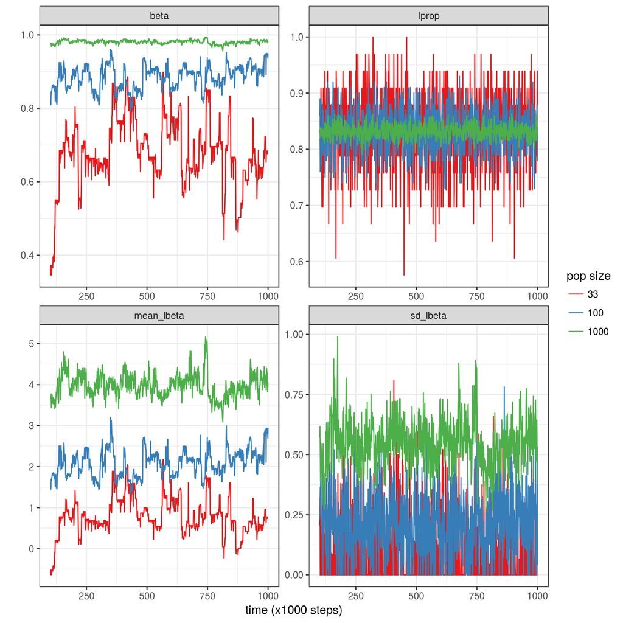

**Notes**

- parameters:
  - $\gamma$ (recovery period) = 1/5
  - $\mu$ (per-infection mutation prob) = 0.01
  - “shift”-type mutation with a logit-Normal shift probability (see below) with mean=-1, standard deviation=0.5
  - 1 million time steps, reported every 1000 steps
  - initial $R_0$=2 (plot below omits first 100,000 steps, so this isn’t visible), except for $N=33$ (boosted to 4 to prevent extinction)
- I’m dealing with $\beta$ (*per capita* infection probabilities) on the logit scale, which makes it much easier to allow mutation on an unconstrained scale (i.e. not worrying about probabilities <0 or >1). Back-transforming summaries of the logit-beta distribution, e.g. going from mean(logit-beta) to mean(beta), is therefore not entirely accurate; we could deal with this in a variety of ways (computing and storing desired summaries on the appropriate scale during the simulation run, or using the delta method). This also means the amount of mutation (on the $\beta$/probability scale) varies according to the base $\beta$; as $\beta$ approaches 0 or 1, the scope for mutation is smaller.
- first panel shows $\beta$; $\beta$ values this close to 1 give rise to *extremely* high $R_0$ values (since $R_0 = \beta N/\gamma$, $1/\gamma=5$ in this example). “Unrealistic” in some sense … would the results be different if we used an SIRS model (and left individuals in a Resistant state for some period of time)? In any case, it does make sense that $\beta$ is smaller for $N=100$ than $N=1000$ (more drift).
- Not sure why infection proportion is so similar for different $\beta$; would expect that infection proportion would go down? Also, would expect much higher $I^*/N$ ($*$ denotes equilibrium): expected is $1-1/R_0$ … Is this another effect of variability? (**New hypothesis**: since we’re in discrete time, even if we had 100% infection, a fraction $1/\gamma$ of individuals would be recovering at each time step, so we’d have about a fraction $1-1/\gamma$ infected - $\approx 0.8$ as observed in this case - but why is the infected proportion slightly *higher* than 80%? Is there something funky about the sequence of events/census time, are mutations being counted differently, etc.?)
- standard deviation of logistic-beta is higher in larger population (not just sure if that’s what I expected but …). Not sure if this is a reliable summary (i.e., how is distribution skewed etc.?) Could save more summary statistics about the shape of the distribution, or save a snapshot of the final distribution - saving the entire distribution for every time step could be pretty unwieldy.
- Would be nice to speed up the code (takes about 2-4 minutes per run; increases with pop size, but sublinearly)

These are the distributions of $\beta$ and $\log_{10}(R_0)$ (the latter certainly needs to be taken with a grain of salt …)

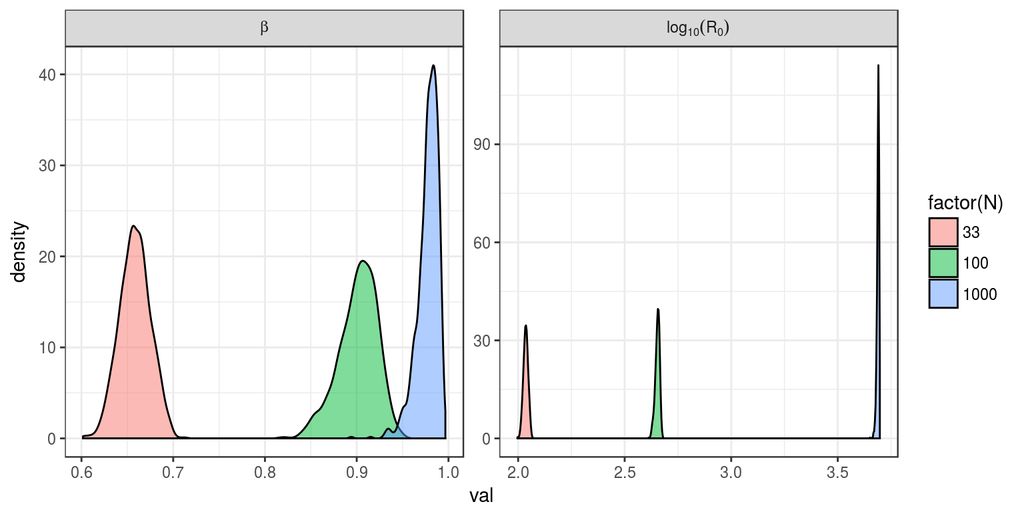

## Latin hypercube runs

Run simulations across a broad range of parameters:

| var | min | max |
| --- | --- | --- |
| gamma | 0.100 | 0.500 |
| mu | 0.001 | 0.100 |
| mut_mean | -4.000 | -0.500 |
| mut_sd | 0.100 | 3.162 |
| N | 3.000 | 1000.000 |

For each run, compute the mean infection proportion, mean(mean logit-beta), and mean(std dev logit-beta) for the last 10% (last 100,000 steps out of a million).

Haven’t spent enough time to figure out what’s going on here yet …

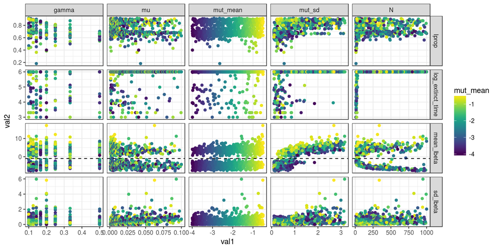

Compare high-transmission-equilibrium (red) vs low-transmission equilibrium (blue). Add proportion infected to the plot …

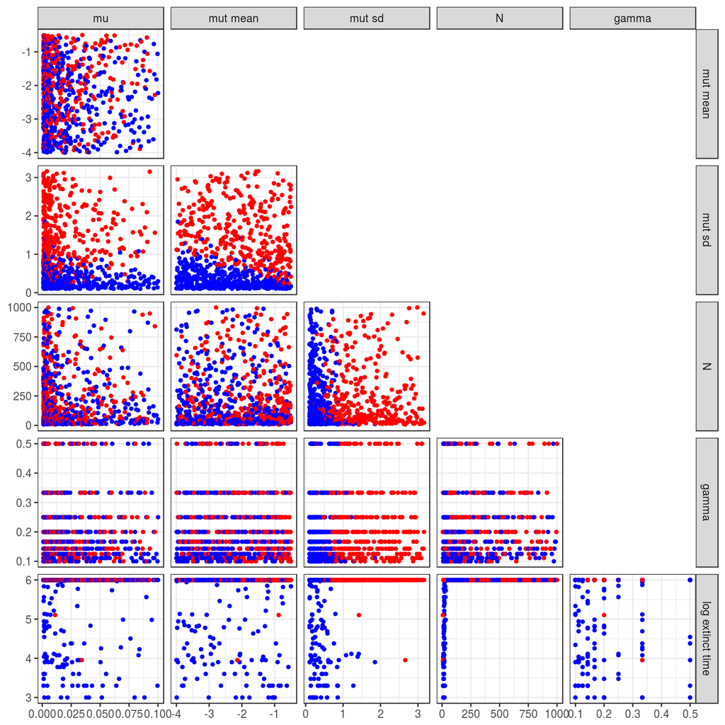

A prototype of a better? way to plot these …

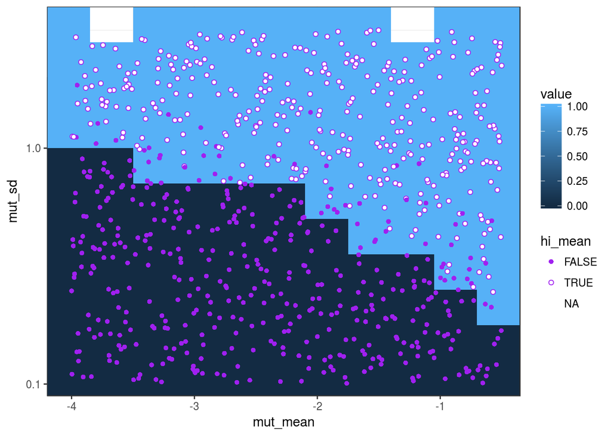

## Variable-$\gamma$ models

Preliminary results for allowing infectious period to mutate: everybody gets infected, all the time! Infectious period ($1/\gamma$) just keeps increasing … (becomes very, very long).

I’ve also run the latin hypercube runs for the variable-gamma case, but I’m not sure I want to worry about the results until I’ve understood what’s going on in this case. Related to the details of order/what the effective $R_0$ etc. is in this particular discret-time model?

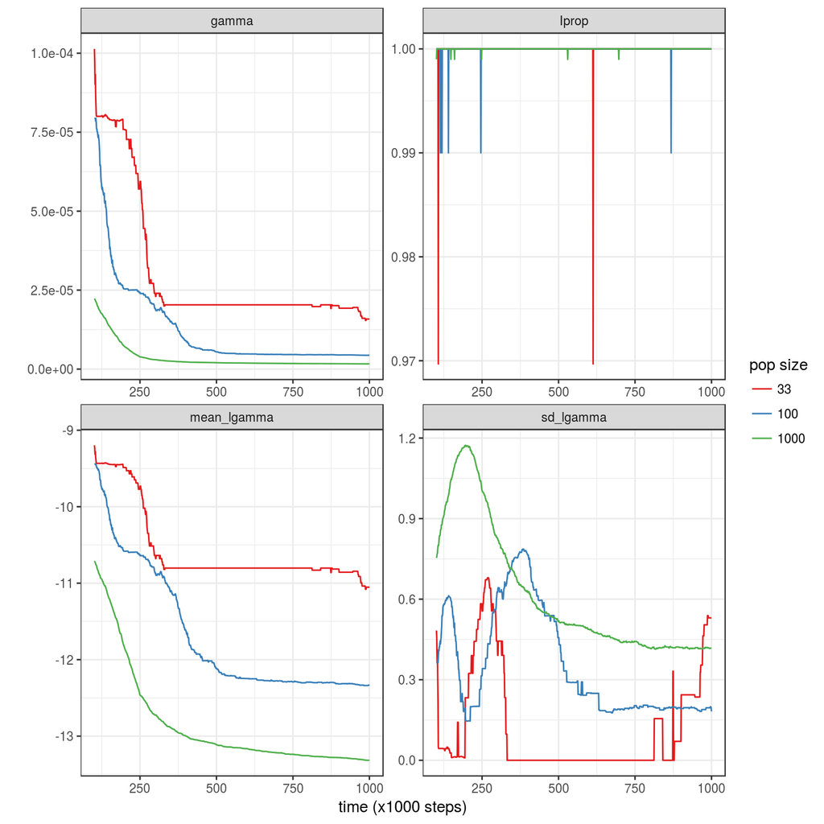

## To do

- figure out bimodality in results for equilibrium transmission
  - seems to have something to do with standard deviation of mutation; low values
  - redo plots as binned average plots (red-blue gradient)
  - redo sims with continuously varying $\gamma$
- understand $\gamma$ results
  - $\gamma$ evolution with logit link, maximum value
  - step through one iteration; asymmetry between $\beta$ and $\gamma$?
- continuous-time equivalent?
- keep track of extinctions?
- SIRS?
- keep track of lineage age?
- output final distribution?
- change the mutational model (e.g. Ornstein-Uhlenbeck, $0 \le \alpha \le 1$)
- make the code faster